# Applying k-Nearest Neighbors to predict the success of a marketing campaign k

#Applying k-Nearest Neighbors to predict the success of a marketing campaign For this assignment, we will be using the bank marketing dataset from UCI. The data has 17 attributes and is related to marketing campaigns (phone calls) of a Portuguese banking institution. The classification goal is to predict if the client will subscribe a term deposit (variable y). Please download and unzip the dataset from here: https://archive.ics.uci.edu/ml/machine-learning-databases/00222/ . The dataset you will be working on is stored in bank-full.csv. Data Exploration Open the file bank-names.txt and carefully read the attribute information to understand what information is stored in each attribute, what values each attribute can take and so on.

```r
install.packages(c("ggplot2","rpart","carData","class","caTools","caret"))
```

```
Error in install.packages : Updating loaded packages
```

```r
bank_data <- read.csv("bank-full.csv",sep = ";",header = TRUE)

head(bank_data)
```

|  | age | job | marital | education | default | balance | housing | loan | contact | day | month | duration | campaign | pdays | previous | poutcome | y |
| --- | --- | --- | --- | --- | --- | --- | --- | --- | --- | --- | --- | --- | --- | --- | --- | --- | --- |
| 1 | 58 | management | married | tertiary | no | 2143 | yes | no | unknown | 5 | may | 261 | 1 | -1 | 0 | unknown | no |
| 2 | 44 | technician | single | secondary | no | 29 | yes | no | unknown | 5 | may | 151 | 1 | -1 | 0 | unknown | no |
| 3 | 33 | entrepreneur | married | secondary | no | 2 | yes | yes | unknown | 5 | may | 76 | 1 | -1 | 0 | unknown | no |
| 4 | 47 | blue-collar | married | unknown | no | 1506 | yes | no | unknown | 5 | may | 92 | 1 | -1 | 0 | unknown | no |
| 5 | 33 | unknown | single | unknown | no | 1 | no | no | unknown | 5 | may | 198 | 1 | -1 | 0 | unknown | no |
| 6 | 35 | management | married | tertiary | no | 231 | yes | no | unknown | 5 | may | 139 | 1 | -1 | 0 | unknown | no |

```r
str(bank_data)
```

[output not shown]

```r
summary(bank_data)
```

```
      age            job              marital           education           default             balance         housing
 Min.   :18.00   Length:45211       Length:45211       Length:45211       Length:45211       Min.   : -8019   Length:45211
 1st Qu.:33.00   Class :character   Class :character   Class :character   Class :character   1st Qu.:    72   Class :character
 Median :39.00   Mode  :character   Mode  :character   Mode  :character   Mode  :character   Median :   448   Mode  :character
 Mean   :40.94                                                                               Mean   :  1362
 3rd Qu.:48.00                                                                               3rd Qu.:  1428
 Max.   :95.00                                                                               Max.   :102127
     loan             contact               day           month              duration         campaign          pdays
 Length:45211       Length:45211       Min.   : 1.00   Length:45211       Min.   :   0.0   Min.   : 1.000   Min.   : -1.0
 Class :character   Class :character   1st Qu.: 8.00   Class :character   1st Qu.: 103.0   1st Qu.: 1.000   1st Qu.: -1.0
 Mode  :character   Mode  :character   Median :16.00   Mode  :character   Median : 180.0   Median : 2.000   Median : -1.0
                                       Mean   :15.81                      Mean   : 258.2   Mean   : 2.764   Mean   : 40.2
                                       3rd Qu.:21.00                      3rd Qu.: 319.0   3rd Qu.: 3.000   3rd Qu.: -1.0
                                       Max.   :31.00                      Max.   :4918.0   Max.   :63.000   Max.   :871.0
    previous          poutcome              y
 Min.   :  0.0000   Length:45211       Length:45211
 1st Qu.:  0.0000   Class :character   Class :character
 Median :  0.0000   Mode  :character   Mode  :character
 Mean   :  0.5803
 3rd Qu.:  0.0000
 Max.   :275.0000
```

Get the frequency table of the target variable “y” to see how many observations you have in each category of y. Is y balanced? that is, do you have roughly same observations in y=yes and y=no?

```r
table(bank_data$y)
```

```
   no   yes
39922  5289
```

Explore the data in order to investigate the association between the target variable y and other variables in the dataset. Which of the other variables are associated with y? Use appropriate plots and statistic tests to answer this question.

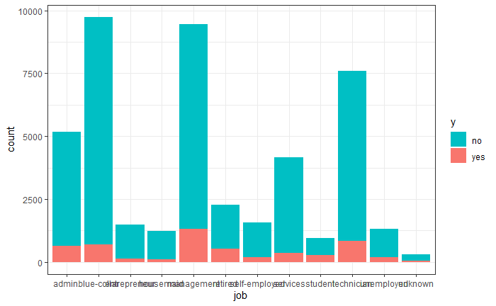

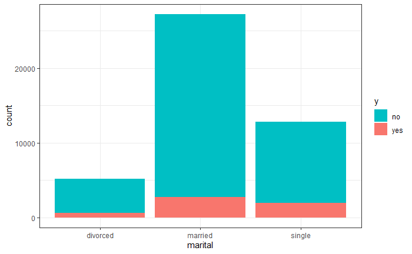

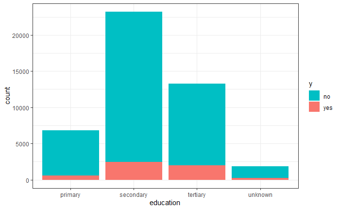

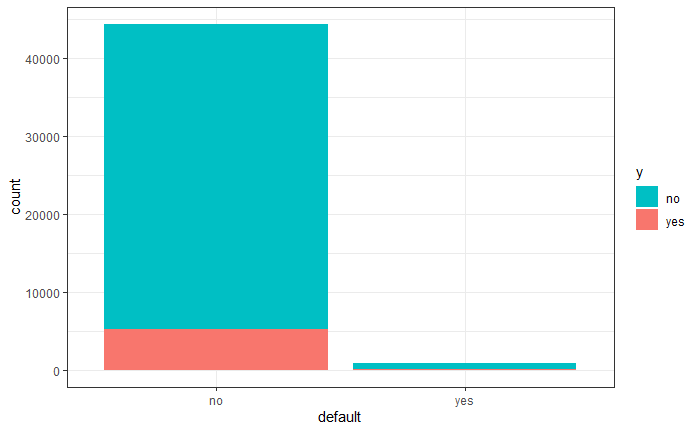

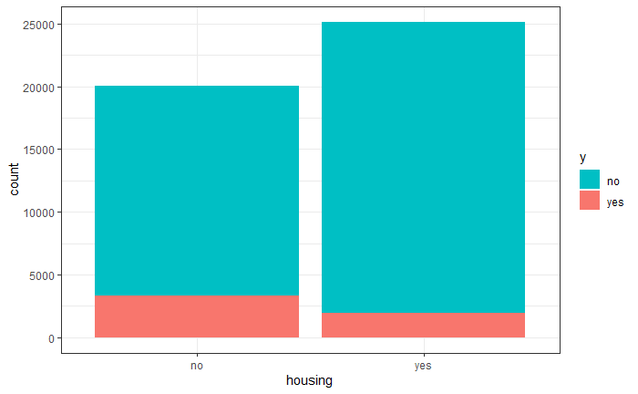

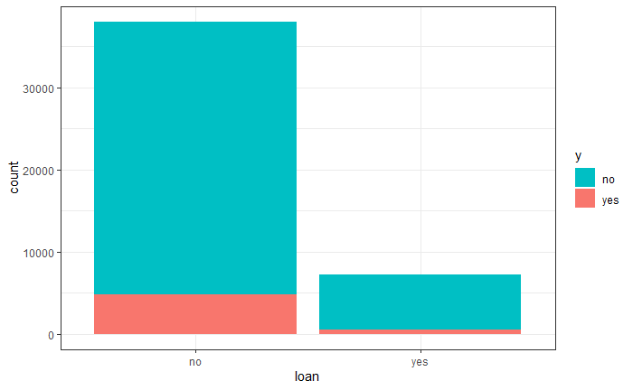

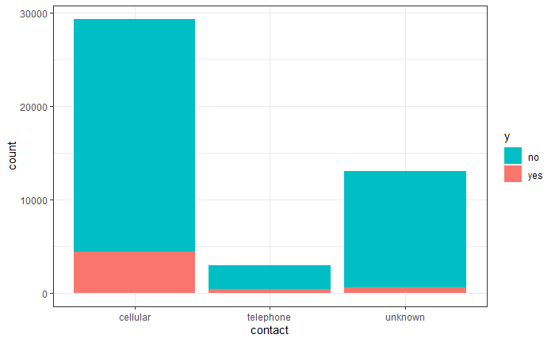

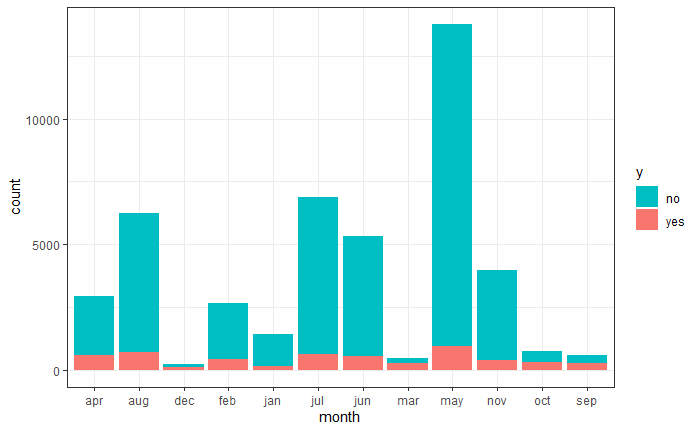

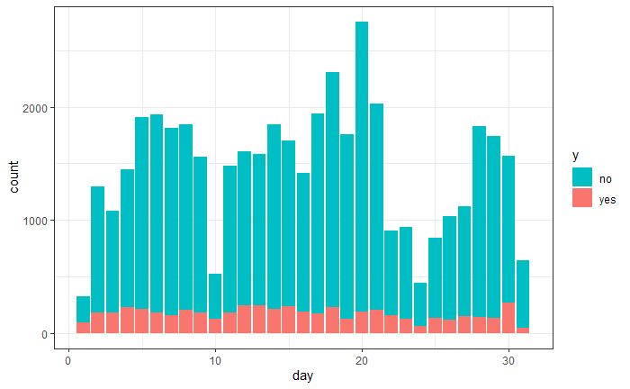

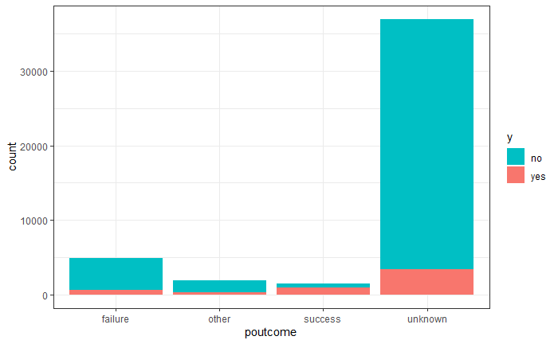

```r
library(ggplot2)

# Create a barplot of y based on each categorical variable in the dataset
categorical_vars <- c("job", "marital", "education", "default", "housing", "loan", "contact", "month", "day", "poutcome")

for(var in categorical_vars) {
  p <- ggplot(data = bank_data, aes_string(x = var, fill = "y")) +
    geom_bar() +
    scale_fill_manual(values = c("#00BFC4", "#F8766D")) +
    theme_bw()
  print(p)
}
install.packages(c("ggplot2", "rpart", "carData", "class", "caTools", "caret"))
```

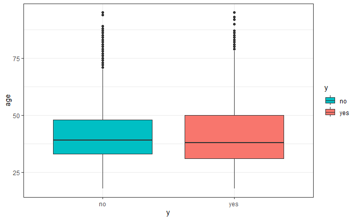

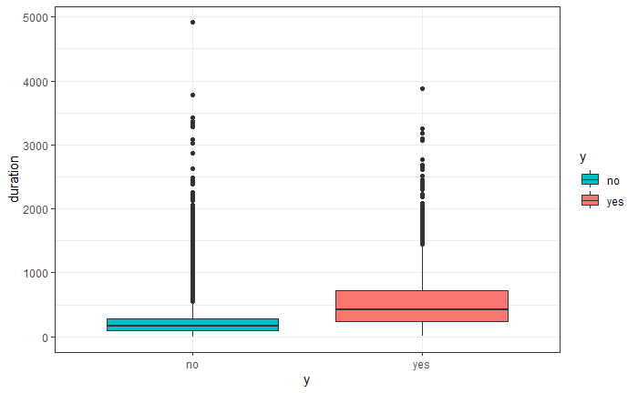

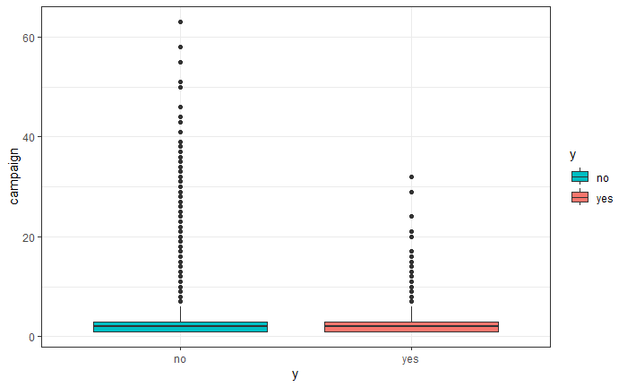

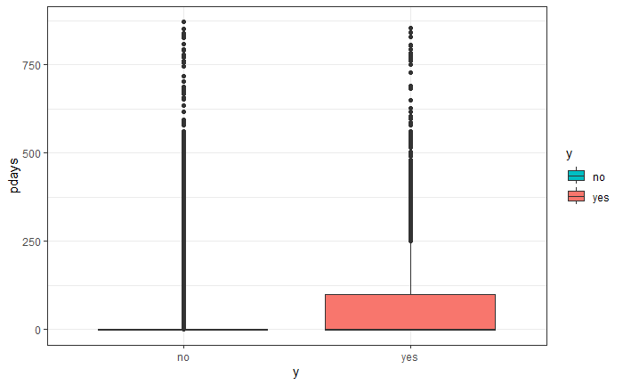

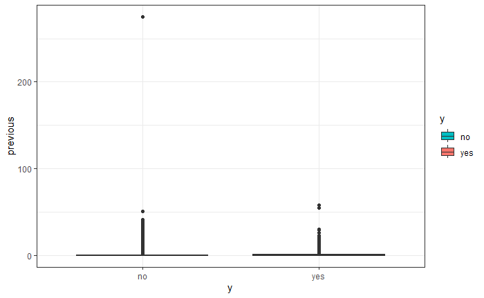

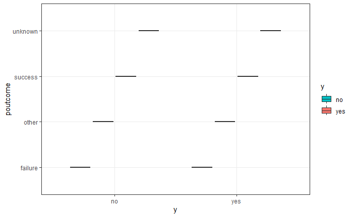

```r
# Create boxplot of y based on each continuous variable in the dataset
continuous_vars <- c("age", "duration", "campaign", "pdays", "previous", "poutcome")

for(var in continuous_vars) {
  p <- ggplot(data = bank_data, aes_string(x = "y", y = var, fill = "y")) +
    geom_boxplot() +
    scale_fill_manual(values = c("#00BFC4", "#F8766D")) +
    theme_bw()
  print(p)
}
```

#Data Preparation Use the command colSums(is.na() to get the number of missing values in each column of your dataframe. Which columns have missing values? Note: some variables use “unknown” for missing values. Convert all “unknown” values to NA. You can do so by setting “na.strings” parameter to “unknown” when you read the file using read.csv.

```r
colSums(is.na(bank_data))
```

```
      age       job   marital education   default   balance   housing      loan   contact       day     month  duration  campaign
        0         0         0         0         0         0         0         0         0         0         0         0         0
    pdays  previous  poutcome         y
        0         0         0         0
```

```r
# Read the dataset again and convert "unknown" values to NA
bank_data <- read.csv("bank-full.csv", sep=";", na.strings = c("unknown"))
str(bank_data)
```

[output not shown]

```r
# Get the number of missing values in each column
colSums(is.na(bank_data))
```

[output not shown]

```r
install.packages("Hmisc")
```

```r
Mode <- function(x) {
  ux <- unique(x)
  ux[which.max(tabulate(match(x, ux)))]
}
```

```r
library(Hmisc)
# Replace missing values in numerical columns with column means
bank_data[, sapply(bank_data, is.numeric)] <- impute(bank_data[, sapply(bank_data, is.numeric)], fun=mean)

# Replace missing values in categorical columns with column modes
bank_data[, sapply(bank_data, is.factor)] <- impute(bank_data[, sapply(bank_data, is.factor)], fun=Mode)

# Check if there are still missing values
colSums(is.na(bank_data))
```

[output not shown]

```r
# Replace missing values in numerical columns with the mean of the column
num_cols <- c("age", "duration", "campaign", "pdays", "previous")
for (col in num_cols) {
  bank_data[[col]][is.na(bank_data[[col]])] <- mean(bank_data[[col]], na.rm = TRUE)
}
# Replace missing values in categorical columns with the mode/majority of the column
cat_cols <- c("job", "marital", "education", "default", "housing", "loan", "poutcome","contact")
for (col in cat_cols) {
  bank_data[[col]][is.na(bank_data[[col]])] <- names(sort(-table(bank_data[[col]])))[1]
}

# Check the number of missing values in each column again
colSums(is.na(bank_data))
```

[output not shown]

Set the seed of the random number generator to a fixed integer, say 1, so that I can reproduce your work: Randomize the order of rows

```r
set.seed(123)

# Randomize the order of the rows in the dataframe
bank_data <- bank_data[sample(nrow(bank_data)), ]
```

One way to deal with categorical variables is to assign numeric indices to each level. However, this imposes an artificial ordering on an unordered categorical variable. For example, suppose that we have a categorical variable primary color with three levels: “red”,”blue”,”green”. If we convert “red” to 0 , “blue” to 1 and “green” to 2 then we are telling our model that red < blue< green which is not correct. A better way to encode an unordered categorical variable is to do one-hot-encoding. In one hot-encoding we create a dummy binary variable for each level of a categorical variable. Do one-hot-encoding of all your unordered categorical variables (except the target variable y). You can use the function one_hot from mltools package to one-hot encode all categorical variables in a dataset.

```r
# Load the data.table and mltools packages
library(data.table)
library(mltools)

# Convert the dataframe to a data.table

# Define the columns that contain unordered categorical variables
unordered_cols <- c("job", "marital", "education","default", "housing", "loan", "contact", "month", "day_of_week", "poutcome", "y")
ncol(unordered_cols)
```

```r
unordered_cols
```

```
 [1] "job"         "marital"     "education"   "default"     "housing"     "loan"        "contact"     "month"       "day_of_week"
[10] "poutcome"    "y"
```

```r
unordered_cols <- as.data.table(unordered_cols)
# One-hot-encode the unordered categorical variables
bank_data_onehot <- one_hot( unordered_cols )
```

[output not shown]

```r
bank_data_one_hot
```

[output not shown]

Split the data into training and test sets. Use the first 36168 rows for training and the rest for testing.

```r
# Get the number of rows in the dataset
num_rows <- nrow(bank_data_onehot)
num_rows
```

```
[1] 11
```

```r
# Split the data into training and test sets
train_indices <- 1:36168
test_indices <- (36169:num_rows)

train_data <- bank_data_onehot[train_indices, ]
test_data <- bank_data_onehot[test_indices, ]
ncol(train_data)
```

```
[1] 1
```

```r
ncol(test_data)
```

```
[1] 1
```

```r
train_labels <- as.factor(bank_data$y)
```

Scale all numeric features using z-score normalization. Note: Don’t normalize your one-hot-encoded variables.

```r
library(data.table)

# Define numeric columns
numeric_cols <- names(train_data)[sapply(train_data, is.numeric)]

# Scale numeric columns using z-score normalization
train_data[, (numeric_cols) := lapply(.SD, scale), .SDcols = numeric_cols]
test_data[, (numeric_cols) := lapply(.SD, scale), .SDcols = numeric_cols]
# Replace the original numeric variables with the scaled variables in the training dataset
#train_data[, numeric_cols] <- scaled_numeric_data
```

```r
sum(is.na(train_labels))
```

```
[1] 0
```

```r
nrow(train_data)
```

```
[1] 36168
```

```r
nrow(train_labels)
```

```r
library(caret)
# Define training control parameters
ctrl <- trainControl(method = "cv", number = 5)

# Fit KNN model with cross-validation
fit <- train(x=train_data, y=train_labels , method = "knn", trControl = ctrl, preProcess = c("center", "scale"))
```

```
Error in check_dims(x = x, y = y) : nrow(x) == n is not TRUE
```